# Mapping STI policy capacity building initiatives and exploring its transformative value for the SDGs initiatives

## Total Dataset

The following results present the characteristics of global STI capacity building initiatives collected by the researchers following a web scraping exercise.

The preview of the data is here! Currently the data is hidden.

| Country of organisation | SDG Connection | Delivery Method | Training Type | Levels | Duration | Target audience | Training provider |
| --- | --- | --- | --- | --- | --- | --- | --- |
| Japan | High | In Person | Degree | Advanced | 1 year + | Students | Academic institution |
| Belgium (EU) | High | Online - Teams | Workshop | Intermediate | < 1 week | Professionals | Non-governmental agency |
| South Africa | High | In Person | Short Course | Advanced | < 1 month | Professionals | Academic institution |
| UK | Low | In Person | Degree | Advanced | 1 year + | Students | Academic institution |
| USA | Medium | In Person | Degree | Advanced | 1 year + | Students | Academic institution |
| South Korea | High | Online - Others | Workshop | Advanced | < 1 week | Professionals | Non-governmental agency |
| USA | Medium | Online - Others | MOOC | Intermediate | < 3 months | Professionals | Private organisation |
| UK | Medium | In Person | Workshop | Intermediate | < 1 week | Professionals | Academic institution |
| Russia | Medium | In Person | Degree | Advanced | 1 year + | Students | Academic institution |
| Canada | Medium | Online - Others | Short Course | Advanced | < 3 months | Professionals | Academic institution |
| UK | Medium | Guidebook | Guidebook | Advanced | NA | Professionals | Academic institution |
| USA | Medium | Online - Others | Workshop | Advanced | < 1 week | Professionals | Academic institution |
| USA | Medium | In Person | Degree | Advanced | 1 year + | Students | Academic institution |
| UK | High | In Person | Degree | Advanced | < 1 year | Students | Academic institution |
| UK | Medium | Online - Zoom | Short Course | Advanced | < 1 week | Professionals | Academic institution |
| China | Medium | In Person | Short Course | Intermediate | < 1 week | Professionals | Academic institution |
| UK | Medium | In Person | Short Course | Intermediate | < 1 week | Professionals | Academic institution |
| USA | High | Online - Others | Short Course | Intermediate | < 3 months | Professionals | Academic institution |
| France | High | Online - Others | Short Course | Advanced | < 6 months | Other | Non-governmental agency |
| USA | Medium | Online - Others | Short Course | Advanced | < 1 month | Students | Academic institution |
| USA | High | Online - Others | Short Course | Intermediate | Unspecified | General | Non-governmental agency |
| USA | Medium | Online - Others | Degree | Advanced | < 3 months | Students | Academic institution |
| USA | Medium | In Person | Degree | Advanced | 1 year + | Students | Academic institution |
| USA | Medium | In Person | Degree | Advanced | 1 year + | Students | Academic institution |
| USA | Low | In Person | Degree | Advanced | 1 year + | Students | Academic institution |
| Pakistan | Low | In Person | Degree | Advanced | 1 year + | Students | Academic institution |
| USA | Low | Online - Zoom | MOOC | Intermediate | < 1 week | Students | Academic institution |
| UK | Low | Online - Zoom | Degree | Advanced | 1 year + | Students | Academic institution |
| USA | Low | In Person | Degree | Advanced | 1 year + | Students | Academic institution |
| USA | High | Online - Teams | Workshop | Advanced | < 1 week | General | Non-governmental agency |

[output cut: 68 more lines]

## Summary Statistics

### Total Topic

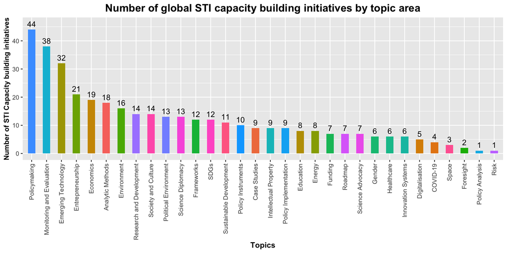

### Training Provider

The number of global STI capacity building initiatives according to the type of training institution.

| Training provider | Number of initiatives |
| --- | --- |
| Academic institution | 52 |
| Government agency | 12 |
| Non-governmental agency | 32 |
| Other | 1 |
| Private organisation | 1 |

### Delivery Method

The number of global STI capacity building initiatives according to the type of delivery method.

| Delivery Method | Number of initiatives |
| --- | --- |
| In Person | 58 |
| Online - Others | 20 |
| Online - Zoom | 12 |
| Online - Teams | 6 |
| Publication | 1 |

### Training Type

The number of global STI capacity building initiatives according to the type of training.

| Training Type | Number of initiatives |
| --- | --- |
| Workshop | 40 |
| Short Course | 27 |
| Degree | 26 |
| Guidebook | 3 |
| MOOC | 2 |

### Level

The number of global STI capacity building initiatives according to the level of STI expertise required. The ‘advanced’ level indicates that the course covers STI policy best practice, emerging issues, case studies, indicators of success and how to track impact, whilst targeting individuals with a high level of knowledge and expertise. The ‘intermediate’ level covers the basics of STI policy and some prior knowledge of policymaking is desirable for participation. The ‘basic’ level covers the very basics of policymaking and barriers to entry are very low as no prior knowledge and experience are required.

| Levels | Number of initiatives |
| --- | --- |
| Advanced | 46 |
| Intermediate | 35 |
| Basic | 17 |

### Countries

The number of global capacity building initiatives according to the country of the training provider.

| Countries | Number of initiatives |
| --- | --- |
| US | 23 |
| UK | 13 |
| India | 7 |
| Russia | 5 |
| Japan | 4 |
| France | 4 |
| Thailand | 3 |
| South Africa | 3 |
| Pakistan | 3 |
| South Korea | 3 |
| Ethiopia | 3 |
| China | 3 |
| Switzerland | 2 |
| Belgium | 2 |
| Canada | 1 |
| New Zealand | 1 |
| Malaysia | 1 |
| Netherlands | 1 |
| Australia | 1 |
| Bosnia and Herzegovina | 1 |
| Tanzania | 1 |
| Ghana | 1 |
| Kenya | 1 |
| Colombia | 1 |
| Jordan | 1 |
| Brazil | 1 |
| Sri Lanka | 1 |
| Chile | 1 |
| Seychelles | 1 |
| Denmark | 1 |
| Lebanon | 1 |
| Taiwan, China | 1 |
| Republic of Congo | 1 |

### Duration

The number of global STI capacity building initiatives according to their length of duration.

| Row Labels | Number of initiatives |
| --- | --- |
| < 1 week | 50 |
| 1 year + | 22 |
| < 1 month | 8 |
| < 3 months | 7 |
| Unspecified | 5 |
| < 6 months | 3 |
| < 1 year | 2 |

### Locality

The number of global STI capacity building initiatives according to their locality.

| Row Labels | Number of initiatives |
| --- | --- |
| Unspecified | 51 |
| Regional | 31 |
| Country-specific | 16 |

### Target Audience Location

The number of global STI capacity building initiatives according to the location of the target audience.

| Row Labels | Number of initiatives |
| --- | --- |
| Any | 35 |
| Multiple | 15 |
| Unspecified | 10 |
| Africa | 8 |
| USA | 8 |
| India | 5 |
| South East Asia | 2 |
| Europe | 2 |
| Asia Pacific | 2 |
| Jordan | 1 |
| China | 1 |
| East Asia | 1 |
| Canada | 1 |
| Latin America | 1 |
| Thailand | 1 |
| South Asia | 1 |
| Africa | 1 |
| Seychelles | 1 |
| Ghana | 1 |
| Iran | 1 |

### Target Audience

The number of global STI capacity building initiatives according to the type of target audience.

| Target audience | Number of initiatives |
| --- | --- |
| Professionals | 57 |
| Students | 29 |
| General | 10 |
| Other | 2 |

## Topic by Delivery Method

### Workshop

| Row Labels | Workshop |
| --- | --- |
| Monitoring and Evaluation | 20 |
| Policymaking | 11 |
| Analytic Methods | 10 |
| Emerging Technology | 9 |
| SDGs | 8 |
| Entrepreneurship | 7 |
| Policy Implementation | 7 |
| Roadmap | 6 |
| Policy Instruments | 5 |
| Funding | 5 |
| Research and Development | 4 |
| Frameworks | 4 |
| Sustainable Development | 4 |
| Gender | 4 |
| COVID-19 | 4 |
| Environment | 3 |
| Political Environment | 3 |
| Case Studies | 3 |
| Healthcare | 3 |
| Economics | 2 |
| Society and Culture | 2 |
| Education | 2 |
| Science Advocacy | 2 |
| Innovation Systems | 2 |
| Digitalisation | 2 |
| Science Diplomacy | 1 |
| Intellectual Property | 1 |
| Energy | 1 |

### Short Course

| Row Labels | Short Course |
| --- | --- |
| Policymaking | 15 |
| Monitoring and Evaluation | 11 |
| Emerging Technology | 8 |
| Frameworks | 7 |
| Entrepreneurship | 6 |
| Economics | 6 |
| Society and Culture | 5 |
| Political Environment | 5 |
| Sustainable Development | 5 |
| Environment | 4 |
| Research and Development | 4 |
| Science Diplomacy | 4 |
| Intellectual Property | 4 |
| Case Studies | 4 |
| Education | 4 |
| Science Advocacy | 4 |
| SDGs | 3 |
| Analytic Methods | 2 |
| Energy | 2 |
| Funding | 2 |
| Innovation Systems | 2 |
| Digitalisation | 2 |
| Policy Instruments | 1 |
| Policy Implementation | 1 |
| Roadmap | 1 |
| Healthcare | 1 |
| Gender | 1 |
| Space | 1 |
| Foresight | 1 |

### Degree

| Row Labels | Degree |
| --- | --- |
| Policymaking | 14 |
| Emerging Technology | 14 |
| Economics | 8 |
| Environment | 8 |
| Monitoring and Evaluation | 7 |
| Entrepreneurship | 7 |
| Science Diplomacy | 7 |
| Society and Culture | 5 |
| Political Environment | 5 |
| Analytic Methods | 4 |
| Research and Development | 4 |
| Energy | 4 |
| Policy Instruments | 3 |
| Intellectual Property | 3 |
| Sustainable Development | 2 |
| Case Studies | 2 |
| Education | 2 |
| Innovation Systems | 2 |
| Space | 2 |
| SDGs | 1 |
| Policy Implementation | 1 |
| Healthcare | 1 |
| Gender | 1 |
| Digitalisation | 1 |
| Foresight | 1 |
| Policy Analysis | 1 |
| Risk | 1 |

### Guidebook

| Row Labels | Guidebook |
| --- | --- |
| Policymaking | 3 |
| Analytic Methods | 2 |
| Emerging Technology | 1 |
| Entrepreneurship | 1 |
| Economics | 1 |
| Society and Culture | 1 |
| Frameworks | 1 |
| Policy Instruments | 1 |
| Intellectual Property | 1 |
| Energy | 1 |
| Science Advocacy | 1 |
| Healthcare | 1 |

### MOOC

| Row Labels | MOOC |
| --- | --- |
| Economics | 2 |
| Research and Development | 2 |
| Policymaking | 1 |
| Environment | 1 |
| Society and Culture | 1 |
| Science Diplomacy | 1 |

## Topics by SDG Connection

### SDG Connection

The number of global STI capacity building initiatives according to the strength of their connection to the SDGs. A ‘high’ connection indicates that the training is highly relevant to the SDGs and is an explicit connection made in the course title or description. A ‘medium’ connection suggests that sustainability may be a significant focus of the initiative, although there is no explicit connection made to the SDGs. A ‘low’ connection shows that there is little to no mention of sustainability in the course.

[output not shown]

### High

| Row Labels | High |
| --- | --- |
| Policymaking | 10 |
| Monitoring and Evaluation | 10 |
| SDGs | 8 |
| Emerging Technology | 7 |
| Analytic Methods | 5 |
| Political Environment | 5 |
| Sustainable Development | 5 |
| Case Studies | 4 |
| Policy Implementation | 4 |
| Society and Culture | 3 |
| Frameworks | 3 |
| Policy Instruments | 3 |
| Roadmap | 3 |
| Economics | 2 |
| Environment | 2 |
| Research and Development | 2 |
| Science Diplomacy | 2 |
| Healthcare | 2 |
| Gender | 2 |
| Entrepreneurship | 1 |
| Education | 1 |
| Energy | 1 |
| Innovation Systems | 1 |
| Foresight | 1 |

### Medium

| Row Labels | Medium |
| --- | --- |
| Policymaking | 28 |
| Monitoring and Evaluation | 20 |
| Emerging Technology | 18 |
| Entrepreneurship | 15 |
| Analytic Methods | 12 |
| Economics | 10 |
| Environment | 10 |
| Science Diplomacy | 10 |
| Research and Development | 9 |
| Intellectual Property | 8 |
| Society and Culture | 7 |
| Science Advocacy | 7 |
| Frameworks | 6 |
| Education | 5 |
| Political Environment | 4 |
| Sustainable Development | 4 |
| Policy Instruments | 4 |
| Case Studies | 4 |
| Policy Implementation | 4 |
| Funding | 4 |
| Roadmap | 4 |
| Gender | 4 |
| SDGs | 3 |
| Energy | 3 |
| Innovation Systems | 3 |
| Healthcare | 2 |
| Digitalisation | 2 |
| COVID-19 | 1 |
| Space | 1 |
| Foresight | 1 |
| Policy Analysis | 1 |
| Risk | 1 |

### Low

| Row Labels | Low |
| --- | --- |
| Monitoring and Evaluation | 8 |
| Emerging Technology | 7 |
| Economics | 7 |
| Policymaking | 6 |
| Entrepreneurship | 5 |
| Political Environment | 5 |
| Environment | 4 |
| Society and Culture | 4 |
| Funding | 4 |
| Energy | 4 |
| COVID-19 | 4 |
| Research and Development | 3 |
| Frameworks | 3 |
| Policy Instruments | 3 |
| Digitalisation | 3 |
| Sustainable Development | 2 |
| Education | 2 |
| Healthcare | 2 |
| Innovation Systems | 2 |
| Space | 2 |
| Analytic Methods | 1 |
| Science Diplomacy | 1 |
| SDGs | 1 |
| Intellectual Property | 1 |
| Case Studies | 1 |
| Policy Implementation | 1 |